# Reed et al (2010) Notes

# Abstract:

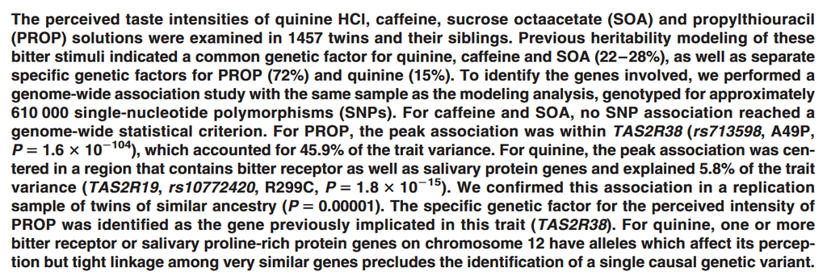

*Abstract of Reed et al (2010)*

# Intro

- PROP/PTC TAS2R38 explains most of the genetic variation, although other modifiers may exist
- Hansen et al. (2006) found a common genetic factor accounting for 22-28% of the variance of caffeine, SOA, and quinine, and a quinine-specific factor accounts for 15% of the variation
  - this study only used modeling, not GWAS/genetics to identify what these factors/genes might be
- aim of this study is to use a GWAS to try to identify the specific genes responsible for the variation seen in Hansen et al. (2006)

# Methods

- used “discovery” and “replicate” samples
  - discovery sample was from Brisbane twin study
  - rep sample was collected from Ohio
- 1 mL sample was used and collected bitterness perception on LMS
  - 1mL is not very much (like the amount of saliva you’d swallow)
- linkage-based analysis for
  - intenisty of quinine
    - no linkage seen at chromosome 12 (likely due to lack of power)
  - intensity of PROP in solution
  - intensity of PROP on paper
    - linkage seen near TAS2R38
- quinine and PROP (solution) did not appear normally distributed
- population stratification had trivial impact on results

# Results

# Discussion

- quinine
  - study suggests proline-rich salivary proteins and bitter taste receptors
  - because of LD, the gene cannot be identified with GWAS alone
- PROP
  - supported that TAS2R38 is responsible for trait variance
  - a region on chromosome 5 approached significance
- adaptation to bitterness may be advantageous
  - sensitivity to bitterness: detect poinous plants/materials
  - decreased sensitivity to bitterness: consume nutritious plants that have toxins
- TAS2Rs are found elsewhere in the body (not limited to oral cavity)
  - nose, lungs, pancreas, GI tract

# Notes

- check out reference 40

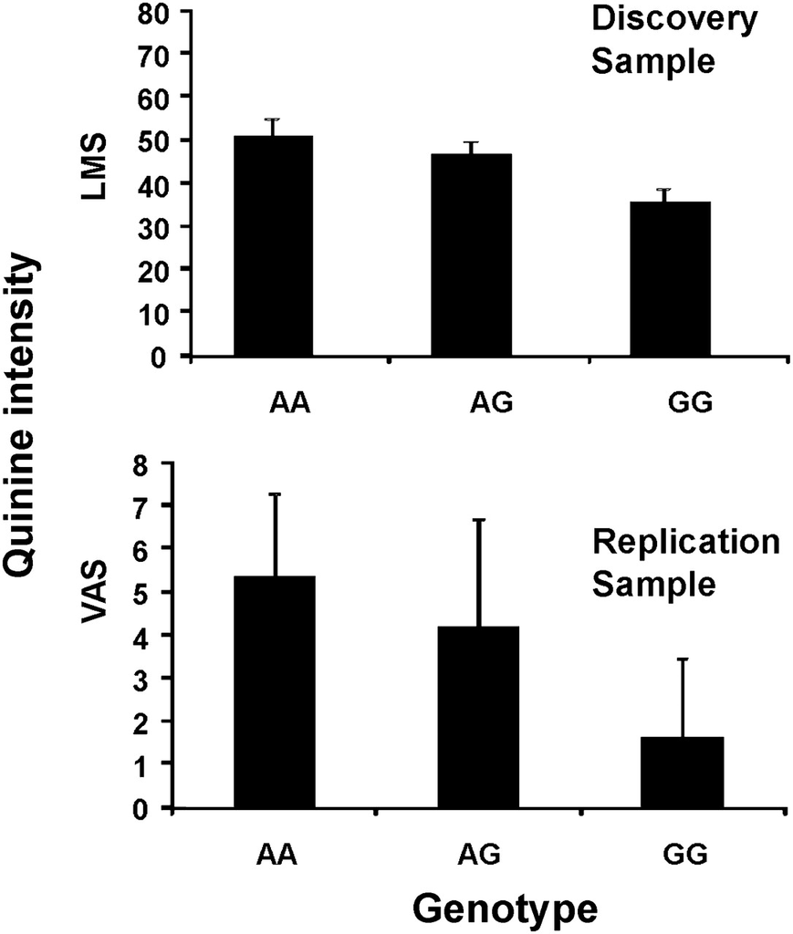

- **Figure 3.** Average bitter taste intensity of quinine as rated by people from the discovery (top) and replication (bottom) samples grouped by their rs10772420 genotype. LMS, labeled magnitude scale; VAS, visual analogue scale. Values are means and confidence intervals corrected for family relationship (upper panel) or means and standard deviations (lower panel). The TAS2R19 A allele corresponds to the cysteine amino acid at position 299 and is associated with more intense perception of quinine in both samples.

  - a great example of what GWAS does

Delwiche, Jeannine F, Zivjena Buletic, and Paul A S Breslin. 2001. “Covariation in Individuals’ Sensitivities to Bitter Compounds: Evidence Supporting Multiple Receptor/Transduction Mechanisms.” *Percept. Psychophys.* 63 (5): 761–76.

Hansen, J. L., Danielle Reed, Margaret Wright, Nicholas Martin, and Paul Breslin. 2006. “Heritability and Genetic Covariation of Sensitivity to Prop, SOA, Quinine Hcl, and Caffeine.” *Chemical Senses* 31 (5): 403–13. https://doi.org/10.1093/chemse/bjj044.